# Bath Air Quality Sensor Failures - where and when?

**Data:** [Bath Hacked Live Air Quality Data](https://data.bathhacked.org/Environment/-Live-Air-Quality-Sensor-Data/hqr9-djir)

**Time Frame:** 30/08/2014 to 6/11/2016

**Preprocessing:** (Python to CSV file)

1. Deleted Royal Victoria Park data (hasn’t worked since 6th October 2014)
2. Deleted entries where pollutants aren’t recorded by sensors (thanks to Tom) - GH/PM10, LR/PM10, LR/CO, LE/CO
3. Data has been split into two groups: part and total failure
4. For part failure error counts from Guidhall and London Road Aurn have been divided by four to account for 15 min v hourly data feeds.
5. Total failures are recorded one per day per station
6. Sensor Stations abbreviated: Guildhall (GH), London Road Enclosure (LE), London Road AURN (LA), Windsor Bridge (WB)

### 1. Part Failure: Sensor producing negative/null values for some but not all pollutants.

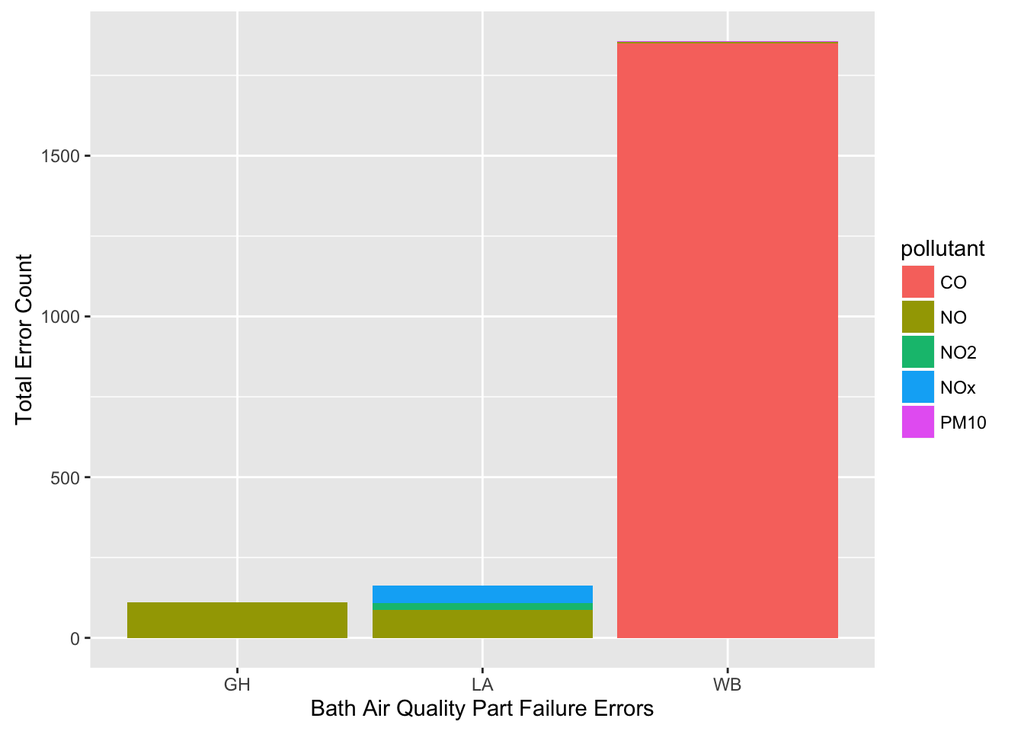

*No part failure errors for London Road Enclosure. If you look at the distribution by quarter (below), you can see the errors above are mostly isolated to 2014.3 and 2014.4*

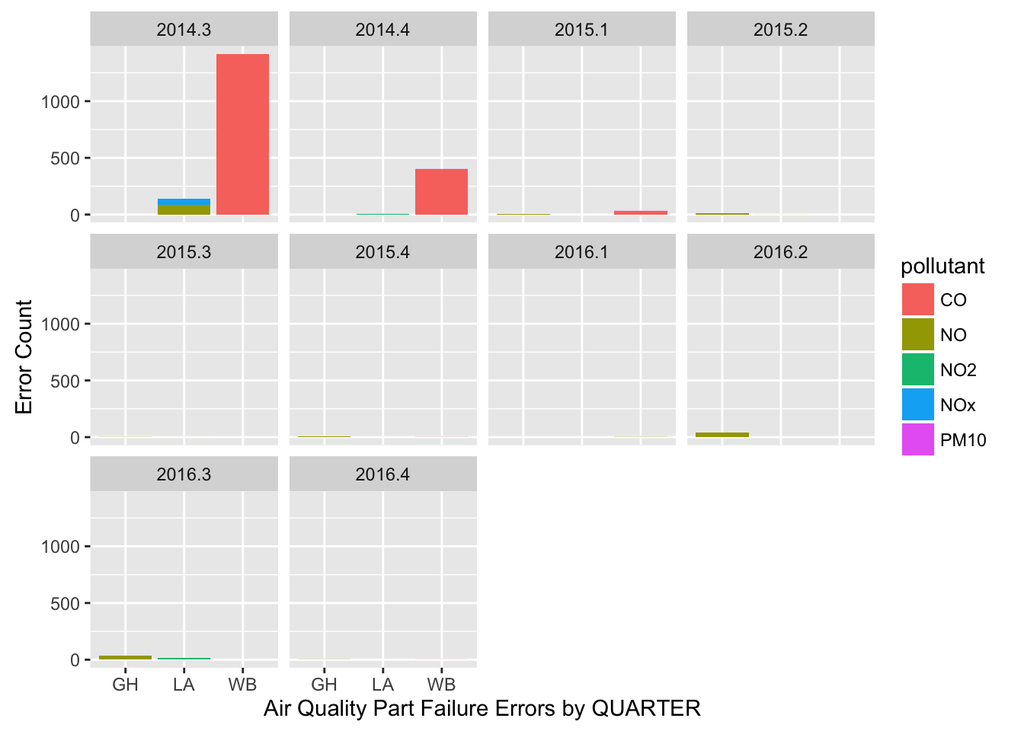

*Without 2014 values, you can see consistent failures in NO readings at Guildhall and some NO2 reading issues at London Road Aurn*

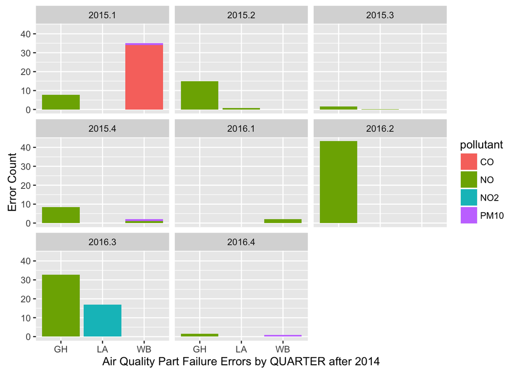

*These seem to be happening in the early hours.*

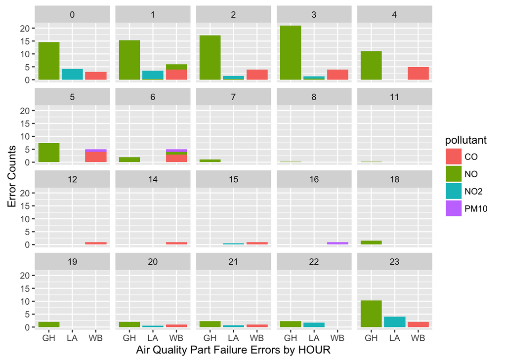

### 2. Total Failure: Sensor producing no valid results, either for some or all of the day.

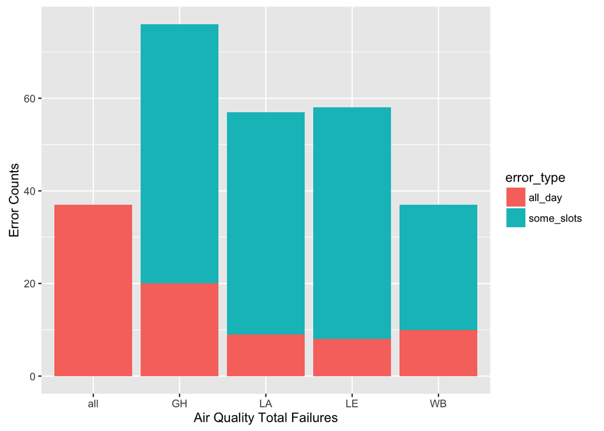

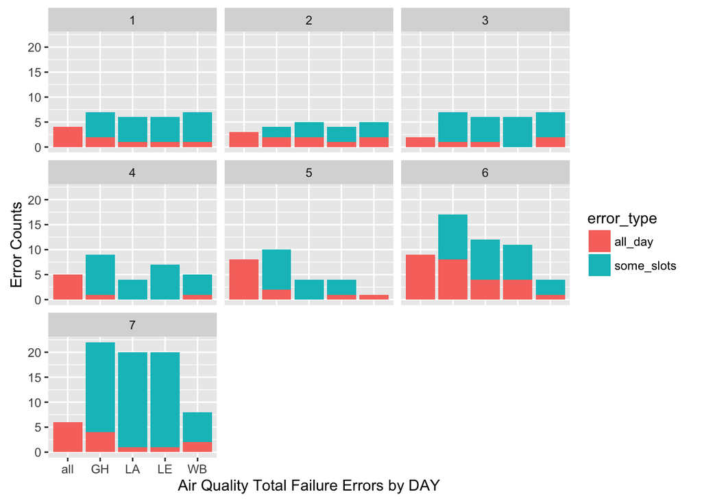

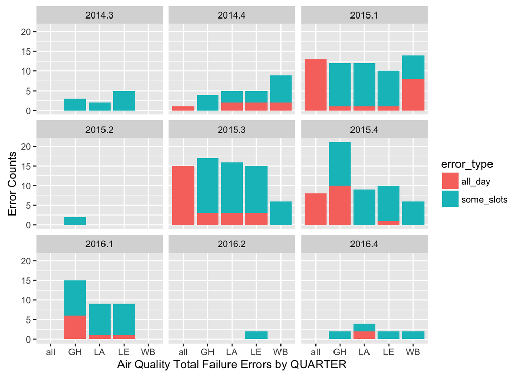

*Finally, the distribution of total failure errors over the time period by station and by error type*

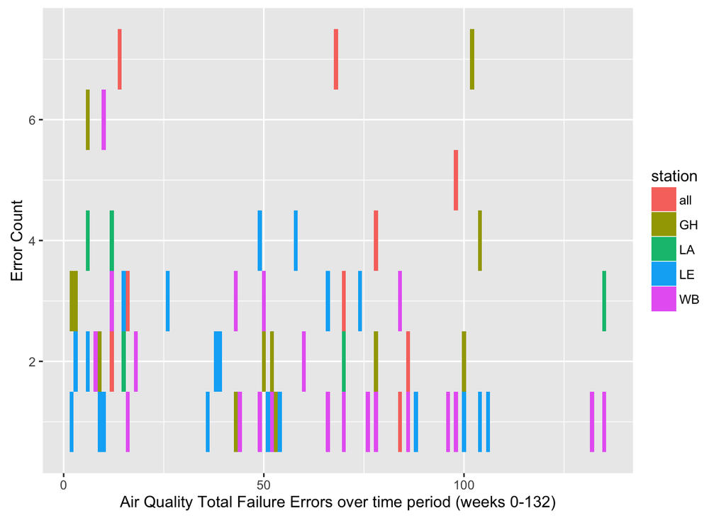

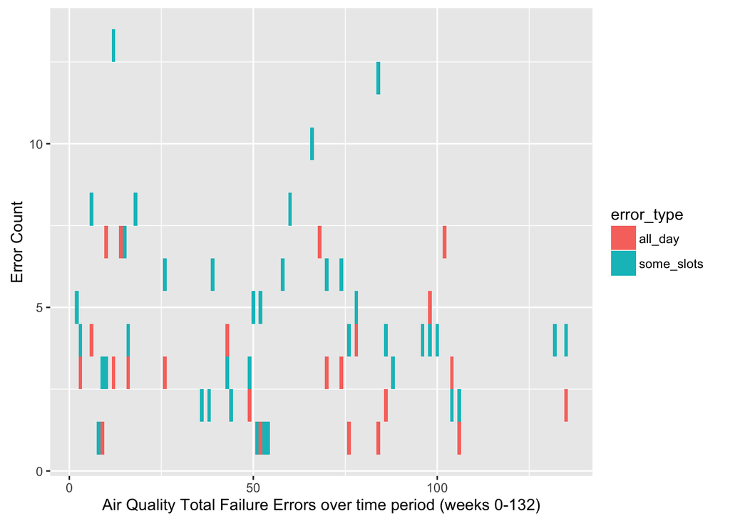